# MA331-Coursework

2110387-Bushra-Hashmi

2022-03-27

This project analyses the word frequencies and sentiment analysis of both the speaker Dan Pallotta and Eric Whitacre. first, we fetch the data from the tidy talks and Tidying and Tokenisation on the talks of the speaker to get the meaningful word of text for analysis. than stopword function is used for removing the not interesting words from the data for the analysis.

To identify both speakers’ top words, this report uses the count function and gets a clear visualisation of the frequencies of the top words. ggplot2 library is used to plot top words from the data into the data frame. To compare the words of Dan Pallotta and Eric Whitacre geom_text_repel() function is used; this function helps select only those words in which the sum of frequencies across the two talks is more than ten times. To Plot the words whose frequencies are more, geom_text_repel() is used from the package ggrepel, words of Dan Pallotta on the Y-axis against words of Eric Whitacre on the x-axis. The graph creates a Red diagonal line with slope = 1.

For Odds ratio and sentiment analysis, this report uses the inner_join function to assign the nrc sentiments. Nrc sentiments categories words into 10 emotions, i.e. positive, negative, anger, anticipation, disgust, fear, joy, sadness, surprise, and trust.

```
## # A tibble: 4 x 5
##   talk_id headline                                     text       speaker  views
##     <dbl> <chr>                                        <chr>      <chr>    <dbl>
## 1    1110 A virtual choir 2,000 voices strong          "I wanted~ Eric W~ 3.61e6
## 2    1688 The way we think about charity is dead wrong "I want t~ Dan Pa~ 4.45e6
## 3    1697 Virtual Choir Live                           "In 1991 ~ Eric W~ 1.04e6
## 4    2497 The dream we haven't dared to dream          "When I t~ Dan Pa~ 1.93e6
```

For analysis of data, we first process of arranging the data into meaningful words of both the speaker through the process of tokenisation.

After the stopwords from the tokenised data is removed. now we filter the frequently used words of each speakers separately.From the talks of Eric Whitacre we selected top 25 words, which he uses most in his speech, the most used word is “Choir”, as Eric has a singing background so that word really represent his personality.

```
## # A tibble: 659 x 3
##    speaker       word        n
##    <chr>         <chr>   <int>
##  1 Eric Whitacre choir      24
##  2 Eric Whitacre singing    17
##  3 Eric Whitacre just       14
##  4 Eric Whitacre people     14
##  5 Eric Whitacre virtual    14
##  6 Eric Whitacre video      13
##  7 Eric Whitacre piece      12
##  8 Eric Whitacre singers    12
##  9 Eric Whitacre thank      12
## 10 Eric Whitacre first      10
## # ... with 649 more rows
```

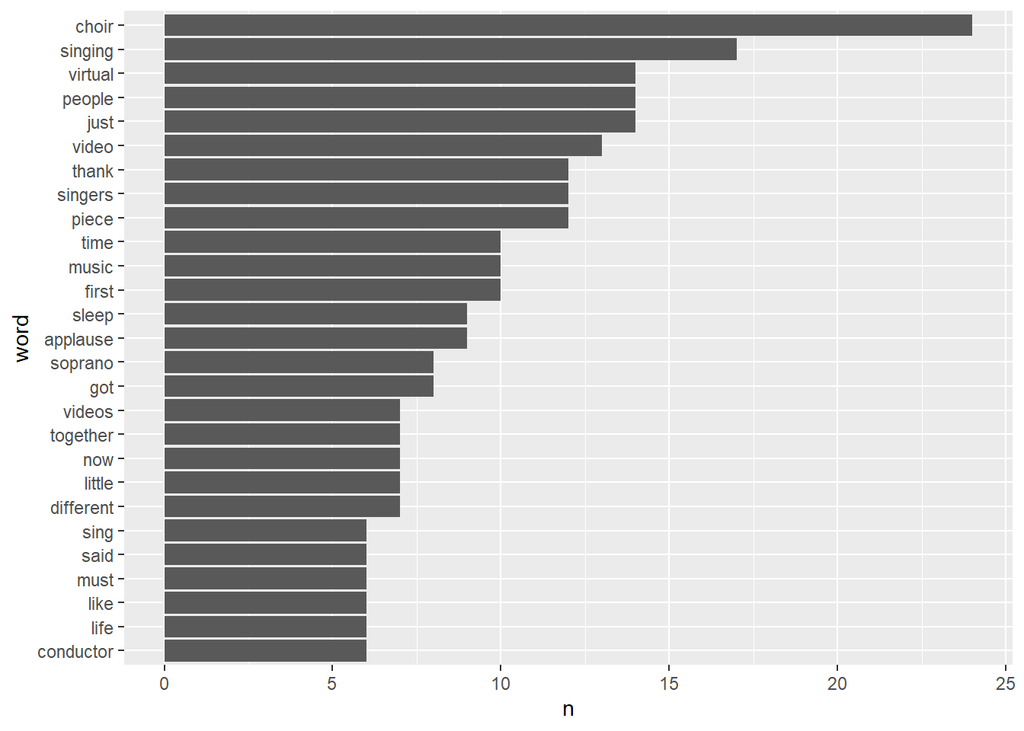

```
## [1] "tbl_df"     "tbl"        "data.frame"
```

From the talks of Dan Pallotta, this report selected top 25 words, which he uses most in his talks, the most used word is “sector”, “Dollar” and “people”.Pallotta talks more focuses on boosting peoples money in the NGO sector and that’s articulated in the Visualisation of his top word.

```
## # A tibble: 1,013 x 3
##    speaker      word         n
##    <chr>        <chr>    <int>
##  1 Dan Pallotta dollars     26
##  2 Dan Pallotta people      26
##  3 Dan Pallotta sector      26
##  4 Dan Pallotta money       21
##  5 Dan Pallotta one         19
##  6 Dan Pallotta profit      18
##  7 Dan Pallotta overhead    17
##  8 Dan Pallotta us          17
##  9 Dan Pallotta want        17
## 10 Dan Pallotta charity     16
## # ... with 1,003 more rows
```

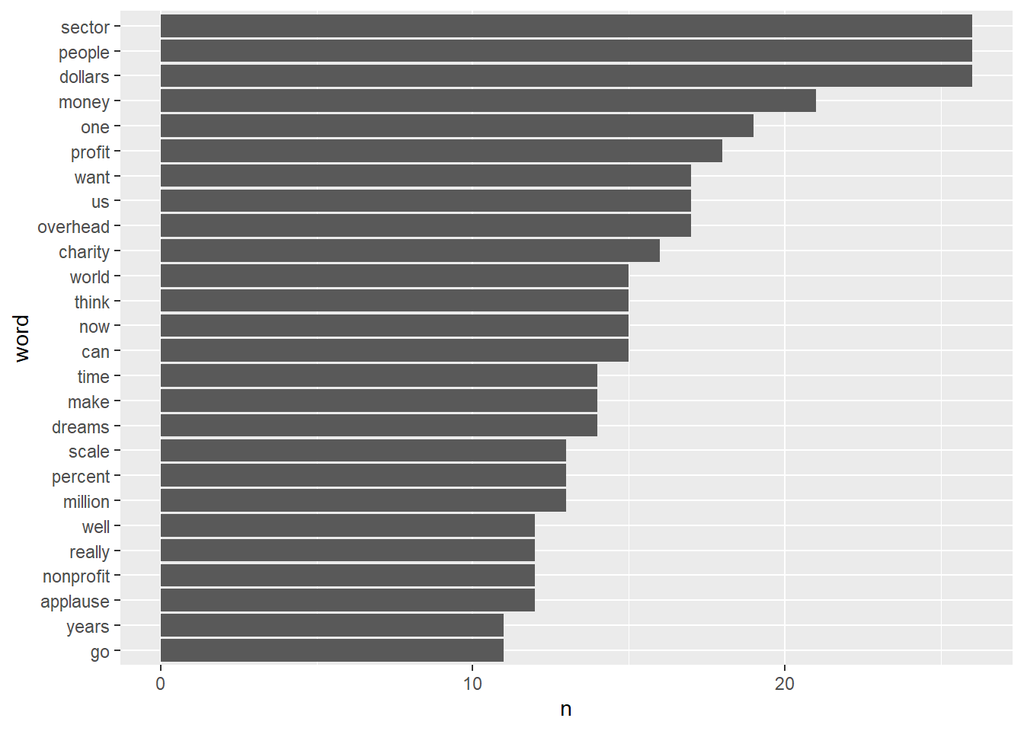

```
## # A tibble: 1,013 x 3
##    speaker      word         n
##    <chr>        <chr>    <int>
##  1 Dan Pallotta dollars     26
##  2 Dan Pallotta people      26
##  3 Dan Pallotta sector      26
##  4 Dan Pallotta money       21
##  5 Dan Pallotta one         19
##  6 Dan Pallotta profit      18
##  7 Dan Pallotta overhead    17
##  8 Dan Pallotta us          17
##  9 Dan Pallotta want        17
## 10 Dan Pallotta charity     16
## # ... with 1,003 more rows
```

After getting top 25 words of both the words, this report compare the words of speaker in one graph, x-axis represent the words of Eric Whitacre and y-axis represent the words of Dan Pallotta,the pivot_wider basically creates the wider table that enables us to have a clear look at the words usage.

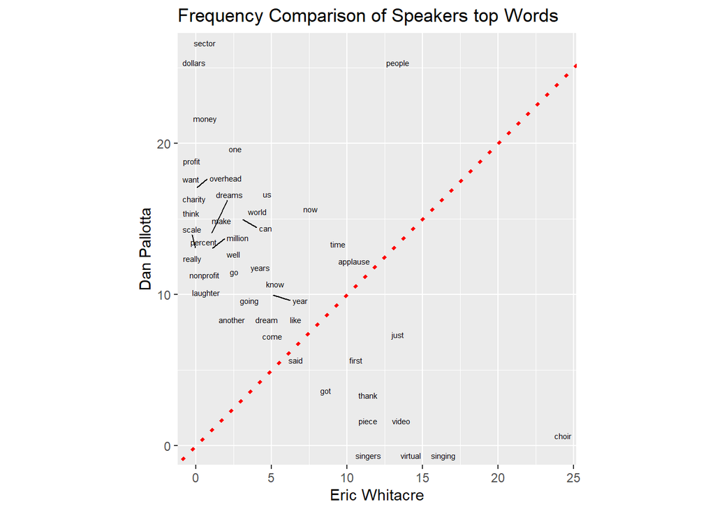

After the visualisation of words, binding the frequently used words of Dan Pallotta and Eric Whitacre and obtaining the sentiments count of their words, inner_join function is used to use different sentiments in our analysis.

```
## # A tibble: 10 x 3
##    sentiment    `Dan Pallotta` `Eric Whitacre`
##    <chr>                 <int>           <int>
##  1 anger                    37               9
##  2 anticipation             51              26
##  3 disgust                  33               3
##  4 fear                     52              10
##  5 joy                      44              33
##  6 negative                 84              21
##  7 positive                127              72
##  8 sadness                  50              12
##  9 surprise                 23              16
## 10 trust                    75              38
```

By using the sentiments data frame, we calculate the odds ratio and log odds ratio for the sentiments of the two respective speakers.

```
## # A tibble: 10 x 5
##    sentiment    `Dan Pallotta` `Eric Whitacre`    OR log_OR
##    <fct>                 <int>           <int> <dbl>  <dbl>
##  1 anger                    37               9 1.76   0.566
##  2 anticipation             51              26 0.800 -0.224
##  3 disgust                  33               3 4.80   1.57
##  4 fear                     52              10 2.28   0.825
##  5 joy                      44              33 0.519 -0.656
##  6 negative                 84              21 1.78   0.577
##  7 positive                127              72 0.660 -0.416
##  8 sadness                  50              12 1.81   0.591
##  9 surprise                 23              16 0.582 -0.541
## 10 trust                    75              38 0.796 -0.228
```

After getting the result of log odds ration, we plot the sentiments on y-axis and log odds ratio on x-axis and from the plot we observe the negative and positive log odds ration of the speakers sentiments.

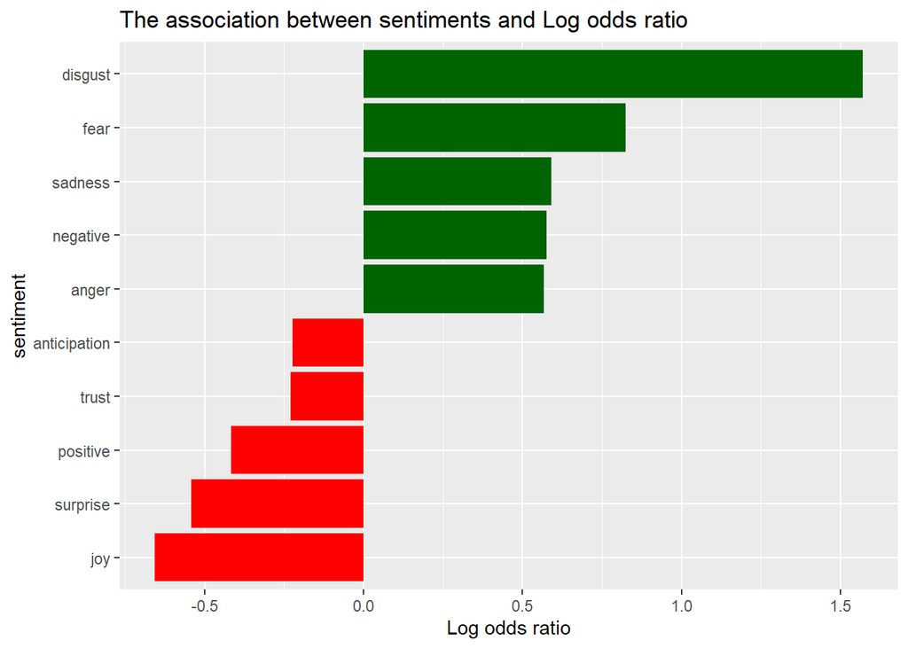

The main challenge was DsEssex package was not showing the data of Ted Talks. Therefore I downloaded it through GitHub and connected it with the main file, later on, software got updated and i get the data in DsEssex library.The another challenge face was Error 99 while converting Rmd file in to Html format, it resolved by changing the list of words into data frame.

In starting of this project, I was a beginner in R language, completing this report was a little bit challenging for me; this report gave confidence in my R language skills, and now it is counted as one of the significant milestones of my life.